# 30-Day Mortality Rate of Cancer Patients Admitted to MICU

Due Sunday, 3/22 @ 11:59 PM

Tony Lim

# Introduction

[MIMIC-III](https://mimic.physionet.org/about/mimic/) ((Medical Information Mart for Intensive Care III)) is a free database compromised of over 40,000 patients seen at critical care units of the Beth Israel Deaconess Medical Center between 2001 and 2012. The current version of the database is [v1.4](https://mimic.physionet.org/about/releasenotes/).

The database includes information such as:

- Demographics
- Vital sign measurements made at the bedside (~1 data point per hour)
- Laboratory test results, procedures
- Medications
- Caregiver notes
- Imaging reports, and
- Mortality (both in and out of hospital)

My research hypothesis predicts that gender will play a significant role in the 30-day mortality rate of patients with cancer admitted to MICU (Medical Intensive Care Unit).

MIMIC-III consists of a total of [40 tables](https://mit-lcp.github.io/mimic-schema-spy/index.html). To address the research hypothesis, this report will only utilize:

- [`ADMISSIONS`](https://mimic.physionet.org/mimictables/admissions/)
- [`D_ICD_DIAGNOSES`](https://mimic.physionet.org/mimictables/d_icd_diagnoses/)
- [`DIAGNOSES_ICD`](https://mimic.physionet.org/mimictables/diagnoses_icd/)
- [`DRGCODES`](https://mimic.physionet.org/mimictables/drgcodes/)
- [`PATIENTS`](https://mimic.physionet.org/mimictables/patients/)
- [`TRANSFERS`](https://mimic.physionet.org/mimictables/transfers/)

# Data preparation

Load database libraries and the tidyverse frontend:

```r
library(DBI)
library(RPostgreSQL)
library(tidyverse)
library(lubridate)
```

Credentials for using PostgreSQL database. We are going to use username `postgres` with password `postgres` to access the `mimic` database in the schemee `mimiciii`.

```r
# Load configuration settings
dbdriver <- 'PostgreSQL'
#host  <- '127.0.0.1'
#port  <- '5432'
user  <- 'postgres'
password <- 'postgres'
dbname <- 'mimic'
schema <- 'mimiciii'
# Connect to the database using the configuration settings
con <- dbConnect(RPostgreSQL::PostgreSQL(),
                 dbname = dbname,
                 #host = host,
                 #port = port,
                 user = user,
                 password = password)
# Set the default schema
dbExecute(con, paste("SET search_path TO ", schema, sep=" "))
```

```
## [1] 0
```

```r
con
```

```
## <PostgreSQLConnection>
```

## Query and subsetting

In this section, we demo how to create a cohort of patients who were directly admitted into MICU and were diagnosed with cancer.

First, we create a (query) table of patients who were directly admitted into MICU.

```r
tbl(con, "transfers") %>%
  select(subject_id, hadm_id, prev_careunit, curr_careunit) %>%
  filter(is.na(prev_careunit) & curr_careunit == "MICU") %>%
  select(subject_id, hadm_id) %>%
  distinct() %>%
  print() -> micu_admissions
```

```
## # Source:   lazy query [?? x 2]
## # Database: postgres 11.0.7 [postgres@/var/run/postgresql:5432/mimic]
##    subject_id hadm_id
##         <int>   <int>
##  1        711  120522
##  2      20863  195453
##  3      97716  178708
##  4      60131  190090
##  5      19705  155006
##  6      11342  165519
##  7      74147  149842
##  8      18958  122966
##  9       7681  175048
## 10      65665  170768
## # … with more rows
```

Now we want to restrict to patients with cancer. To find all possible ICD-9 codes related to cancer, we search for string `neoplasm` in the `long_title` of table `D_ICD_DIAGNOSES`:

```r
tbl(con, "d_icd_diagnoses") %>%
  filter(str_detect(tolower(long_title), "neoplasm")) %>%
  print() -> neo_codes
```

```
## # Source:   lazy query [?? x 4]
## # Database: postgres 11.0.7 [postgres@/var/run/postgresql:5432/mimic]
##    row_id icd9_code short_title        long_title
##     <int> <chr>     <chr>              <chr>
##  1   1349 1709      Malig neopl bone … Malignant neoplasm of bone and articular…
##  2   1246 1590      Malig neo intesti… Malignant neoplasm of intestinal tract, …
##  3   1247 1591      Malignant neo spl… Malignant neoplasm of spleen, not elsewh…
##  4   1248 1598      Mal neo gi/intra-… Malignant neoplasm of other sites of dig…
##  5   1249 1599      Mal neo GI tract … Malignant neoplasm of ill-defined sites …
##  6   1250 1712      Mal neo soft tiss… Malignant neoplasm of connective and oth…
##  7   1251 1713      Mal neo soft tiss… Malignant neoplasm of connective and oth…
##  8   1252 1714      Mal neo soft tis … Malignant neoplasm of connective and oth…
##  9   1253 1715      Mal neo soft tis … Malignant neoplasm of connective and oth…
## 10   1254 1716      Mal neo soft tis … Malignant neoplasm of connective and oth…
## # … with more rows
```

`DIAGNOSES_ICD` table stores the diagnosis of each admission. We use `semi_join()` to keep the rows in `DIAGNOSES_ICD` that match the ICD-9 codes related to cancer:

```r
tbl(con, "diagnoses_icd") %>%
  semi_join(neo_codes, by = "icd9_code") %>%
  print() -> neo_admissions
```

```
## # Source:   lazy query [?? x 5]
## # Database: postgres 11.0.7 [postgres@/var/run/postgresql:5432/mimic]
##    row_id subject_id hadm_id seq_num icd9_code
##     <int>      <int>   <int>   <int> <chr>
##  1 349606      30437  191673       1 1598
##  2 344455      30041  170860       1 1598
##  3 173064      15546  140996      19 1599
##  4 367250      31923  192162      10 1599
##  5 206945      18609  175191       1 1712
##  6 508070      68116  179546       5 1712
##  7 525830      71963  110965       4 1712
##  8  15889       1389  175065       1 1713
##  9  82505       7380  112188       1 1713
## 10 232962      20868  150969       1 1713
## # … with more rows
```

```r
neo_admissions %>%
  filter(seq_num <= 5) %>%
  group_by(subject_id, hadm_id) %>%
  filter(min_rank(seq_num) <= 1) %>%
  ungroup() %>%
  select(subject_id, hadm_id, icd9_code, seq_num) %>%
  print() -> neo_admissions
```

```
## # Source:   lazy query [?? x 4]
## # Database: postgres 11.0.7 [postgres@/var/run/postgresql:5432/mimic]
##    subject_id hadm_id icd9_code seq_num
##         <int>   <int> <chr>       <int>
##  1         11  194540 1913            1
##  2         12  112213 1570            1
##  3         23  124321 2252            1
##  4         41  101757 1917            1
##  5         56  181711 1983            1
##  6         58  177285 2161            2
##  7         84  120969 1919            1
##  8         84  166401 1919            1
##  9        103  130744 1983            1
## 10        103  133550 1983            2
## # … with more rows
```

Now we `inner_join` the table of admissions to MICU and the table of admissions that include neoplasm diagnosis.

```r
micu_admissions %>%
  inner_join(neo_admissions, by = c("subject_id", "hadm_id")) %>%
  print() -> study_admissions
```

```
## # Source:   lazy query [?? x 4]
## # Database: postgres 11.0.7 [postgres@/var/run/postgresql:5432/mimic]
##    subject_id hadm_id icd9_code seq_num
##         <int>   <int> <chr>       <int>
##  1        127  141647 19889           1
##  2        150  108732 1623            1
##  3        170  175350 V1011           4
##  4        184  137477 1919            1
##  5        222  103002 1625            1
##  6        222  188038 1629            4
##  7        249  158975 1534            1
##  8        279  192224 1561            1
##  9        281  111199 1628            3
## 10        291  126219 1983            1
## # … with more rows
```

## Transform and augment query tables

Now we create a logical variable indicating whether cancer is the principal diagonosis or not (according to `seq_num`).

```r
study_admissions %>%
  mutate(principal_dx = seq_num == 1) %>%
  select(-seq_num) %>%
  print() -> study_admissions
```

```
## # Source:   lazy query [?? x 4]
## # Database: postgres 11.0.7 [postgres@/var/run/postgresql:5432/mimic]
##    subject_id hadm_id icd9_code principal_dx
##         <int>   <int> <chr>     <lgl>
##  1        127  141647 19889     TRUE
##  2        150  108732 1623      TRUE
##  3        170  175350 V1011     FALSE
##  4        184  137477 1919      TRUE
##  5        222  103002 1625      TRUE
##  6        222  188038 1629      FALSE
##  7        249  158975 1534      TRUE
##  8        279  192224 1561      TRUE
##  9        281  111199 1628      FALSE
## 10        291  126219 1983      TRUE
## # … with more rows
```

We want to add information about the severity of patients’ ailments. The `DRGCODES` table contains, for `DRG` codes from the All Payers Registry (APR), severity and mortality indicators. We pull the drug severity information and right-join it to our query table.

```r
tbl(con, "drgcodes") %>%
  filter(str_detect(drg_type, "APR")) %>%
  select(subject_id, hadm_id, drg_severity) %>%
  right_join(study_admissions, by = c("subject_id", "hadm_id")) %>%
  mutate(drg_severity = ifelse(is.na(drg_severity), 1, drg_severity)) %>%
  print() -> study_admissions
```

```
## # Source:   lazy query [?? x 5]
## # Database: postgres 11.0.7 [postgres@/var/run/postgresql:5432/mimic]
##    subject_id hadm_id drg_severity icd9_code principal_dx
##         <int>   <int>        <dbl> <chr>     <lgl>
##  1        127  141647            1 19889     TRUE
##  2        150  108732            1 1623      TRUE
##  3        170  175350            1 V1011     FALSE
##  4        184  137477            1 1919      TRUE
##  5        222  103002            3 1625      TRUE
##  6        222  103002            3 1625      TRUE
##  7        222  188038            3 1629      FALSE
##  8        222  188038            3 1629      FALSE
##  9        249  158975            4 1534      TRUE
## 10        249  158975            4 1534      TRUE
## # … with more rows
```

Pull the admission time `admittime`, discharge time `dischtime`, date of birth `dob`, and date of death `dod`. We are interested in the mortaility rate 30 days after discharge. So we only keep patients who didn’t die in hospital.

```r
study_admissions %>%
  left_join(
    select(tbl(con, "admissions"),
           subject_id, hadm_id, admittime, dischtime, hospital_expire_flag
    ), by = c("subject_id", "hadm_id")
  ) %>%
  filter(hospital_expire_flag == 0) %>% # patients who did not die in hospital
  select(-hospital_expire_flag) %>%
  left_join(
    select(tbl(con, "patients"), subject_id, dob, dod),
    by = "subject_id"
  ) %>%
  print(width = Inf) -> study_admissions
```

```
## # Source:   lazy query [?? x 9]
## # Database: postgres 11.0.7 [postgres@/var/run/postgresql:5432/mimic]
##    subject_id hadm_id drg_severity icd9_code principal_dx admittime
##         <int>   <int>        <dbl> <chr>     <lgl>        <dttm>
##  1        127  141647            1 19889     TRUE         2183-08-20 17:25:00
##  2        150  108732            1 1623      TRUE         2161-07-09 17:54:00
##  3        170  175350            1 V1011     FALSE        2189-09-04 12:30:00
##  4        184  137477            1 1919      TRUE         2168-03-13 19:00:00
##  5        222  103002            3 1625      TRUE         2143-02-16 11:20:00
##  6        222  103002            3 1625      TRUE         2143-02-16 11:20:00
##  7        222  188038            3 1629      FALSE        2142-06-23 05:02:00
##  8        222  188038            3 1629      FALSE        2142-06-23 05:02:00
##  9        249  158975            4 1534      TRUE         2156-04-27 15:33:00
## 10        249  158975            4 1534      TRUE         2156-04-27 15:33:00
##    dischtime           dob                 dod
##    <dttm>              <dttm>              <dttm>
##  1 2183-08-24 15:28:00 2135-02-01 00:00:00 2184-02-22 00:00:00
##  2 2161-07-14 14:00:00 2123-09-14 00:00:00 2161-10-13 00:00:00
##  3 2189-09-08 12:30:00 2118-04-03 00:00:00 NA
##  4 2168-03-16 15:45:00 2111-10-16 00:00:00 2168-12-02 00:00:00
##  5 2143-02-25 09:54:00 2073-07-25 00:00:00 2143-03-01 00:00:00
##  6 2143-02-25 09:54:00 2073-07-25 00:00:00 2143-03-01 00:00:00
##  7 2142-07-01 17:30:00 2073-07-25 00:00:00 2143-03-01 00:00:00
##  8 2142-07-01 17:30:00 2073-07-25 00:00:00 2143-03-01 00:00:00
##  9 2156-05-14 15:30:00 2075-03-13 00:00:00 NA
## 10 2156-05-14 15:30:00 2075-03-13 00:00:00 NA
## # … with more rows
```

To add `age` (at admission) variable into the table. [The documentation for the patients table](https://mimic.physionet.org/mimictables/patients/) explains that patients of 90 years and older had their ages artificially inflated, so we remove these patients from the analysis.

```r
study_admissions %>%
  mutate(tt_death = date_part("day", dod) - date_part("day", dischtime)) %>%
  mutate(mortality = tt_death <= 30) %>%
  mutate(age = date_part("year", admittime) - date_part("year", dob)) %>%
  filter(age < 90) %>%
  mutate(age = age - ifelse(
    date_part("month", admittime) < date_part("month", dob) |
      (
        date_part("month", admittime) == date_part("month", dob) &
          date_part("day", admittime) < date_part("day", dob)
      ),
    1,
    0
  )) %>%
  select(-admittime, -dischtime, -dob, -dod, -tt_death) %>%
  select(subject_id, hadm_id, age, mortality, everything()) %>%
  print() -> study_admissions
```

```
## # Source:   lazy query [?? x 7]
## # Database: postgres 11.0.7 [postgres@/var/run/postgresql:5432/mimic]
##    subject_id hadm_id   age mortality drg_severity icd9_code principal_dx
##         <int>   <int> <dbl> <lgl>            <dbl> <chr>     <lgl>
##  1        127  141647    48 TRUE                 1 19889     TRUE
##  2        150  108732    37 TRUE                 1 1623      TRUE
##  3        170  175350    71 NA                   1 V1011     FALSE
##  4        184  137477    56 TRUE                 1 1919      TRUE
##  5        222  103002    69 TRUE                 3 1625      TRUE
##  6        222  103002    69 TRUE                 3 1625      TRUE
##  7        222  188038    68 TRUE                 3 1629      FALSE
##  8        222  188038    68 TRUE                 3 1629      FALSE
##  9        249  158975    81 NA                   4 1534      TRUE
## 10        249  158975    81 NA                   4 1534      TRUE
## # … with more rows
```

Many mortality indicators are missing, due to neither the hospital database nor the social security database having a record of these patients’ deaths. We could convert these to `FALSE` values, but it may be helpful to retain in the analytic table this information on whether deaths were recorded at all, e.g. for validation or sensitivity testing.

Finally, let’s merge some demographic information (ethnicity, gender) into our study `study_admissions`.

```r
tbl(con, "admissions") %>%
  select(subject_id, ethnicity) %>%
  distinct() %>%
  print() -> study_subjects
```

```
## # Source:   lazy query [?? x 2]
## # Database: postgres 11.0.7 [postgres@/var/run/postgresql:5432/mimic]
##    subject_id ethnicity
##         <int> <chr>
##  1       1421 BLACK/AFRICAN AMERICAN
##  2      68255 ASIAN
##  3       4901 WHITE
##  4      81232 WHITE
##  5      28292 WHITE
##  6      21741 WHITE
##  7      12175 BLACK/AFRICAN AMERICAN
##  8        341 BLACK/AFRICAN AMERICAN
##  9      48629 UNABLE TO OBTAIN
## 10      18688 HISPANIC OR LATINO
## # … with more rows
```

```r
tbl(con, "patients") %>%
  select(subject_id, gender) %>%
  distinct() %>%
  full_join(study_subjects, by = "subject_id") %>%
  print() -> study_subjects
```

```
## # Source:   lazy query [?? x 3]
## # Database: postgres 11.0.7 [postgres@/var/run/postgresql:5432/mimic]
##    subject_id gender ethnicity
##         <int> <chr>  <chr>
##  1      26121 M      WHITE
##  2       7489 F      WHITE
##  3      81661 M      WHITE
##  4      30273 F      WHITE
##  5      55935 F      BLACK/AFRICAN AMERICAN
##  6      63914 M      UNABLE TO OBTAIN
##  7      19393 M      WHITE
##  8      15861 M      WHITE
##  9      12289 F      WHITE
## 10      31927 F      PORTUGUESE
## # … with more rows
```

```r
study_subjects %>%
  semi_join(study_admissions, by = "subject_id") %>%
  print() -> study_subjects
```

```
## # Source:   lazy query [?? x 3]
## # Database: postgres 11.0.7 [postgres@/var/run/postgresql:5432/mimic]
##    subject_id gender ethnicity
##         <int> <chr>  <chr>
##  1      15861 M      WHITE
##  2      90455 F      WHITE
##  3      54805 M      OTHER
##  4       6818 M      WHITE
##  5      73512 M      WHITE
##  6      80286 M      WHITE
##  7      57299 F      WHITE
##  8      21892 F      WHITE
##  9      27758 F      HISPANIC/LATINO - PUERTO RICAN
## 10      95045 M      WHITE
## # … with more rows
```

Let’s resolve some diversity and inconsistency in the `ethnicity` field:

```r
unknown_ethnicity <- c(
  "OTHER",
  "UNABLE TO OBTAIN",
  "UNKNOWN/NOT SPECIFIED",
  "MULTI RACE ETHNICITY",
  "PATIENT DECLINED TO ANSWER",
  "UNKNOWN"
)

study_subjects %>%
  collect() %>%
  mutate(ethnic_group = case_when(
    str_detect(ethnicity, "^ASIAN") ~ "ASIAN",
    str_detect(ethnicity, "^BLACK") ~ "BLACK",
    str_detect(ethnicity, "^HISPANIC") ~ "HISPANIC",
    str_detect(ethnicity, "^WHITE") ~ "WHITE",
    ethnicity %in% unknown_ethnicity ~ NA_character_,
    TRUE ~ NA_character_
  )) %>%
  select(subject_id, gender, ethnic_group) %>%
  print() -> study_subjects
```

```
## # A tibble: 1,716 x 3
##    subject_id gender ethnic_group
##         <int> <chr>  <chr>
##  1        127 F      WHITE
##  2        150 F      <NA>
##  3        170 F      WHITE
##  4        184 M      WHITE
##  5        222 F      WHITE
##  6        249 F      WHITE
##  7        279 M      WHITE
##  8        291 F      WHITE
##  9        307 F      WHITE
## 10        319 F      BLACK
## # … with 1,706 more rows
```

Some patients are coded as belonging to more than one ethnic group. To resolve these inconsistencies, we define a helper function to pick the modal value from a vector of values in R, which can be used by the `summarize()` function to choose one ethnic group for each patient.

```r
most <- function(x) {
  if (all(is.na(x))) return(NA_character_)
  y <- table(x, useNA = "no")
  if (length(which(y == max(y))) > 1) return(NA_character_)
  return(names(y)[which.max(y)])
}

study_subjects %>%
  group_by(subject_id) %>%
  summarize(ethnic_group = most(ethnic_group)) %>%
  ungroup() %>%
  mutate(ethnic_group = ifelse(is.na(ethnic_group), "UNKNOWN", ethnic_group)) %>%
  print() -> subject_ethnic_groups
```

```
## # A tibble: 1,697 x 2
##    subject_id ethnic_group
##         <int> <chr>
##  1        127 WHITE
##  2        150 UNKNOWN
##  3        170 WHITE
##  4        184 WHITE
##  5        222 WHITE
##  6        249 WHITE
##  7        279 WHITE
##  8        291 WHITE
##  9        307 WHITE
## 10        319 BLACK
## # … with 1,687 more rows
```

```r
study_subjects %>%
  select(subject_id, gender) %>%
  left_join(subject_ethnic_groups, by = "subject_id") %>%
  print() -> study_subjects
```

```
## # A tibble: 1,716 x 3
##    subject_id gender ethnic_group
##         <int> <chr>  <chr>
##  1        127 F      WHITE
##  2        150 F      UNKNOWN
##  3        170 F      WHITE
##  4        184 M      WHITE
##  5        222 F      WHITE
##  6        249 F      WHITE
##  7        279 M      WHITE
##  8        291 F      WHITE
##  9        307 F      WHITE
## 10        319 F      BLACK
## # … with 1,706 more rows
```

Now we add the demographic information `gender` and `ethnicity` into our `study_admissions` table:

```r
study_admissions %>%
  left_join(study_subjects, by = "subject_id", copy = TRUE) %>%
  print() -> study_admissions
```

```
## # Source:   lazy query [?? x 9]
## # Database: postgres 11.0.7 [postgres@/var/run/postgresql:5432/mimic]
##    subject_id hadm_id   age mortality drg_severity icd9_code principal_dx gender
##         <int>   <int> <dbl> <lgl>            <dbl> <chr>     <lgl>        <chr>
##  1        127  141647    48 TRUE                 1 19889     TRUE         F
##  2        150  108732    37 TRUE                 1 1623      TRUE         F
##  3        170  175350    71 NA                   1 V1011     FALSE        F
##  4        184  137477    56 TRUE                 1 1919      TRUE         M
##  5        222  103002    69 TRUE                 3 1625      TRUE         F
##  6        222  103002    69 TRUE                 3 1625      TRUE         F
##  7        222  188038    68 TRUE                 3 1629      FALSE        F
##  8        222  188038    68 TRUE                 3 1629      FALSE        F
##  9        249  158975    81 NA                   4 1534      TRUE         F
## 10        249  158975    81 NA                   4 1534      TRUE         F
## # … with more rows, and 1 more variable: ethnic_group <chr>
```

## CONSORT flow diagrams

The following [CONSORT flow diagrams](http://www.consort-statement.org/consort-statement/flow-diagram) plot the flow of data selection of the patient cohort.

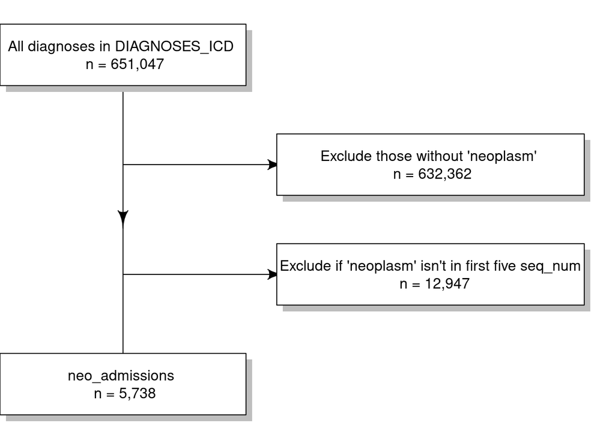

```r
library(shape)
library(diagram)

# set margins and multiplot
par(mfrow = c(1, 1))
par(mar = c(0, 0, 0, 0))

# initialise a plot device
openplotmat()

# position of boxes
# 1st column indicates x axis position between 0 and 1
# 2nd column indicates y axis position between 0 and 1
# automatically assigns vertical position
num_of_boxes <- 4
auto_coords = coordinates(num_of_boxes)
vert_pos = rev(auto_coords[,1])
box_pos <- matrix(nrow = num_of_boxes, ncol = 2, data = 0)
box_pos[1,] = c(0.20, vert_pos[1]) # 1st box
box_pos[2,] = c(0.70, vert_pos[2]) # 2nd box
box_pos[3,] = c(0.70, vert_pos[3]) # 3rd box
box_pos[4,] = c(0.20, vert_pos[4]) # etc...

# content of boxes
box_content <- matrix(nrow = num_of_boxes, ncol = 1, data = 0)
box_content[1] = "All diagnoses in DIAGNOSES_ICD \n n = 651,047" # 1st box
box_content[2] = "Exclude those without 'neoplasm' \n n = 632,362" # 2nd box
box_content[3] = "Exclude if 'neoplasm' isn't in first five seq_num
  n = 12,947" # 3rd box
box_content[4] = "neo_admissions \n n = 5,738"

# adjust the size of boxes to fit content
box_x <- c(0.20, 0.25, 0.25, 0.20)
box_y <- c(0.07, 0.07, 0.07, 0.07)

# Draw the arrows
straightarrow(from = c(box_pos[1,1],box_pos[2,2]), to = box_pos[2,], lwd = 1)
straightarrow(from = c(box_pos[1,1],box_pos[3,2]), to = box_pos[3,], lwd = 1)
straightarrow(from = c(box_pos[1,1],box_pos[4,2]), to = box_pos[4,], lwd = 1)
straightarrow(from = box_pos[1,], to = box_pos[4,], lwd = 1)

# Draw the boxes
for (i in 1:num_of_boxes) {
  textrect(mid = box_pos[i,], radx = box_x[i], rady = box_y[i],
           lab = box_content[i],
           shadow.col = "grey")
  }
```

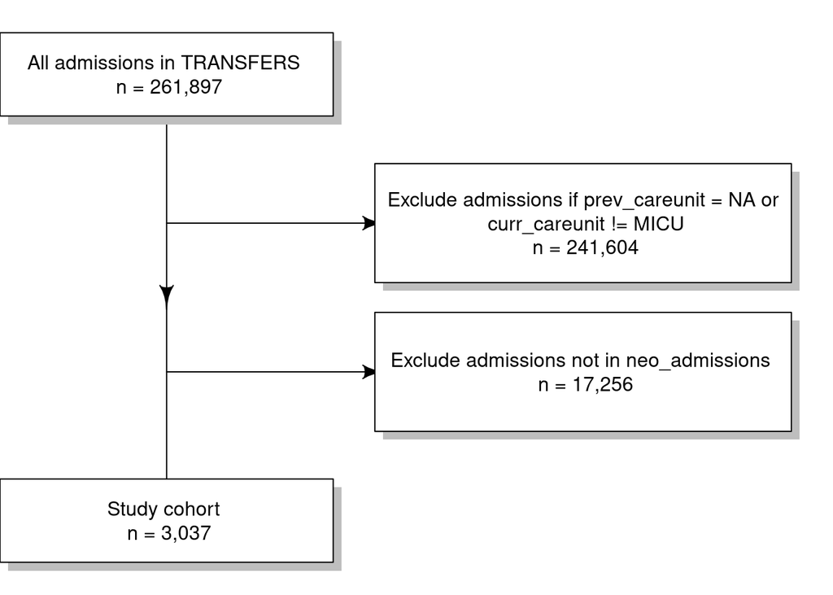

```r
# set margins and multiplot
par(mfrow = c(1, 1))
par(mar = c(0, 0, 0, 0))

# initialise a plot device
openplotmat()

# position of boxes
# 1st column indicates x axis position between 0 and 1
# 2nd column indicates y axis position between 0 and 1
# automatically assigns vertical position
num_of_boxes <- 4
auto_coords = coordinates(num_of_boxes)
vert_pos = rev(auto_coords[,1])
box_pos <- matrix(nrow = num_of_boxes, ncol = 2, data = 0)
box_pos[1,] = c(0.20, vert_pos[1]) # 1st box
box_pos[2,] = c(0.70, vert_pos[2]) # 2nd box
box_pos[3,] = c(0.70, vert_pos[3]) # 3rd box
box_pos[4,] = c(0.20, vert_pos[4]) # etc...

# content of boxes
box_content <- matrix(nrow = num_of_boxes, ncol = 1, data = 0)
box_content[1] = "All admissions in TRANSFERS \n n = 261,897"
box_content[2] = "Exclude admissions if prev_careunit = NA or
  curr_careunit != MICU \n n = 241,604"
box_content[3] = "Exclude admissions not in neo_admissions \n n = 17,256"
box_content[4] = "Study cohort \n n = 3,037"

# adjust the size of boxes to fit content
box_x <- c(0.20, 0.25, 0.25, 0.20)
box_y <- c(0.07, 0.10, 0.10, 0.07)

# Draw the arrows
straightarrow(from = c(box_pos[1,1],box_pos[2,2]), to = box_pos[2,], lwd = 1)
straightarrow(from = c(box_pos[1,1],box_pos[3,2]), to = box_pos[3,], lwd = 1)
straightarrow(from = c(box_pos[1,1],box_pos[4,2]), to = box_pos[4,], lwd = 1)
straightarrow(from = box_pos[1,], to = box_pos[4,], lwd = 1)

# Draw the boxes
for (i in 1:num_of_boxes) {
  textrect(mid = box_pos[i,], radx = box_x[i], rady = box_y[i],
           lab = box_content[i],
           shadow.col = "grey")
  }
```

# Data visualization

## Age

The age distribution appears to be skewed to the left with a median age of 65.

```r
a <- as_tibble(study_admissions %>%
  arrange(subject_id, desc(age)) %>%
  group_by(subject_id) %>%
  filter(row_number() == 1))

median(a$age, na.RM = TRUE)
```

```
## [1] 65
```

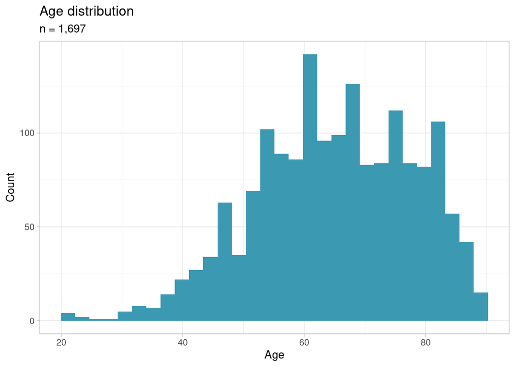

```r
study_admissions %>%
  arrange(subject_id, desc(age)) %>%
  group_by(subject_id) %>%
  filter(row_number() == 1) %>%
  ggplot +
  geom_histogram(mapping = aes(x = age), fill = "#3C99B2") +
  labs(title = "Age distribution",
       subtitle = "n = 1,697",
       x = "Age",
       y = "Count") +
  theme_light()
```

## Gender

There are more males than females in the study cohort.

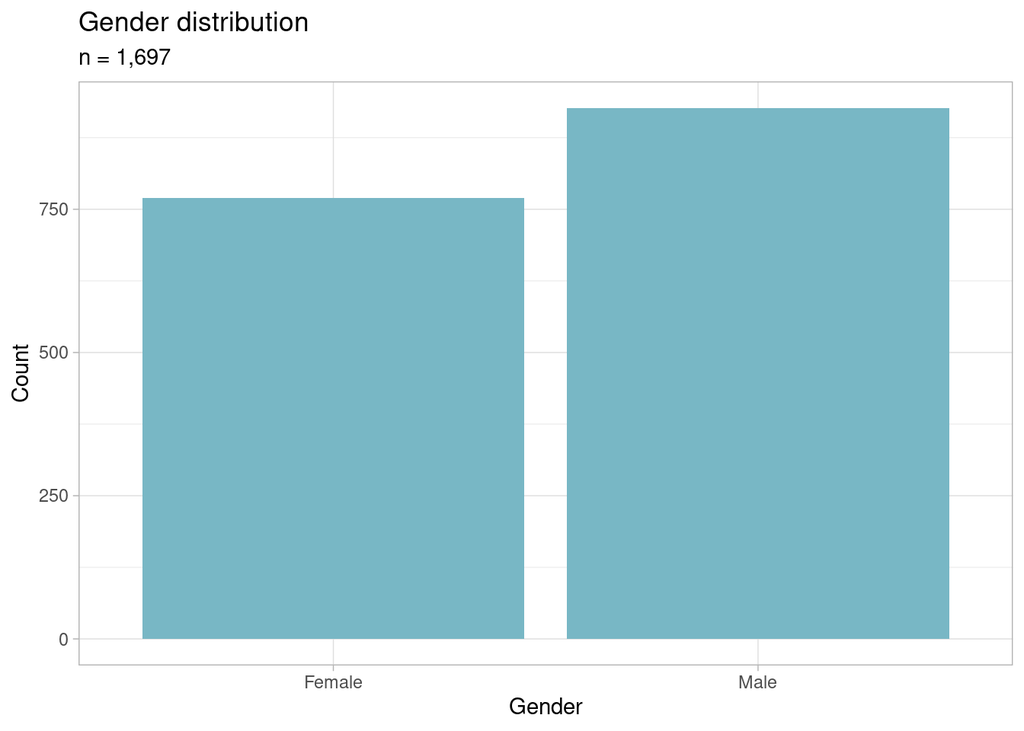

```r
study_admissions %>%
  arrange(subject_id) %>%
  group_by(subject_id, gender) %>%
  filter(row_number() == 1) %>%
  ggplot +
  geom_bar(mapping = aes(x = gender), fill = "#78b7c5") +
  labs(title = "Gender distribution",
       subtitle = "n = 1,697",
       x = "Gender",
       y = "Count") +
  scale_x_discrete(labels = c("Female", "Male")) +
  theme_light()
```

## Ethnicity

The majority of patients in the study cohort falls under the ethnicity category of white.

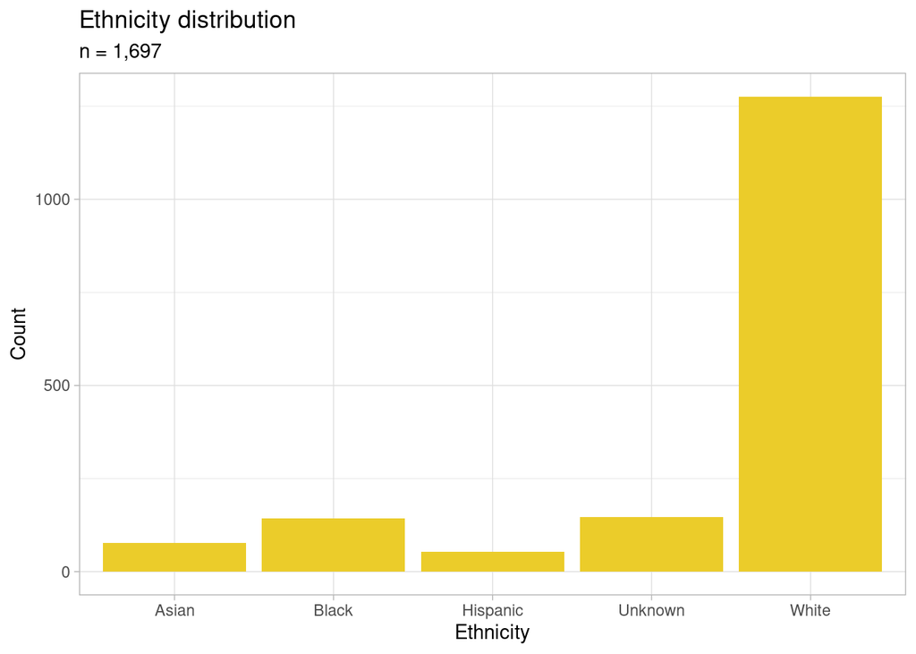

```r
study_admissions %>%
  arrange(subject_id) %>%
  group_by(subject_id, ethnic_group) %>%
  filter(row_number() == 1) %>%
  ggplot +
  geom_bar(mapping = aes(x = str_to_sentence(ethnic_group)), fill = "#EBCC2A") +
  labs(title = "Ethnicity distribution",
       subtitle = "n = 1,697",
       x = "Ethnicity",
       y = "Count") +
  theme_light()
```

## DRG severity

In the study cohort, the DRG severity of cancer was more frequent for severities 1, 3, and 4 than for 2. Furthermore, we see that in each DRG severity category, the proportion of males and females are relatively equal except for severity 4, where there is a higher proportion of males.

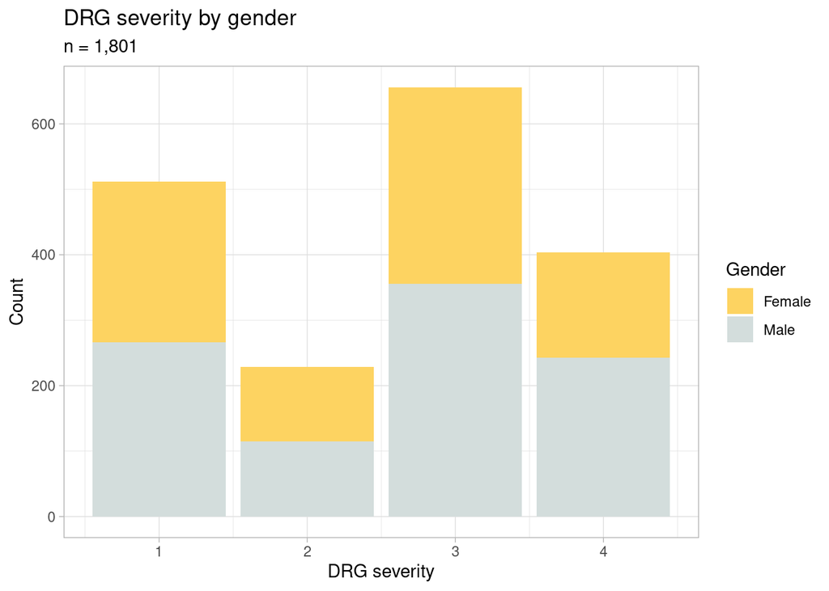

```r
study_admissions %>%
  arrange(subject_id, desc(drg_severity)) %>%
  group_by(subject_id, drg_severity) %>%
  filter(row_number() == 1) %>%
  ggplot +
  geom_bar(mapping = aes(x = drg_severity, fill = gender)) +
  scale_fill_manual(name = "Gender",
                    values = c("#FDD361","#D3DDDC"),
                    labels = c("Female", "Male")) +
  labs(title = "DRG severity by gender",
       subtitle = "n = 1,801",
       x = "DRG severity",
       y = "Count") +
  theme_light()
```

## Principal diagnosis

For patients where cancer is not the principal diagnosis, there is a higher proportion of males. For patients where cancer is the principal diagnosis, the proportion of females and males are equal.

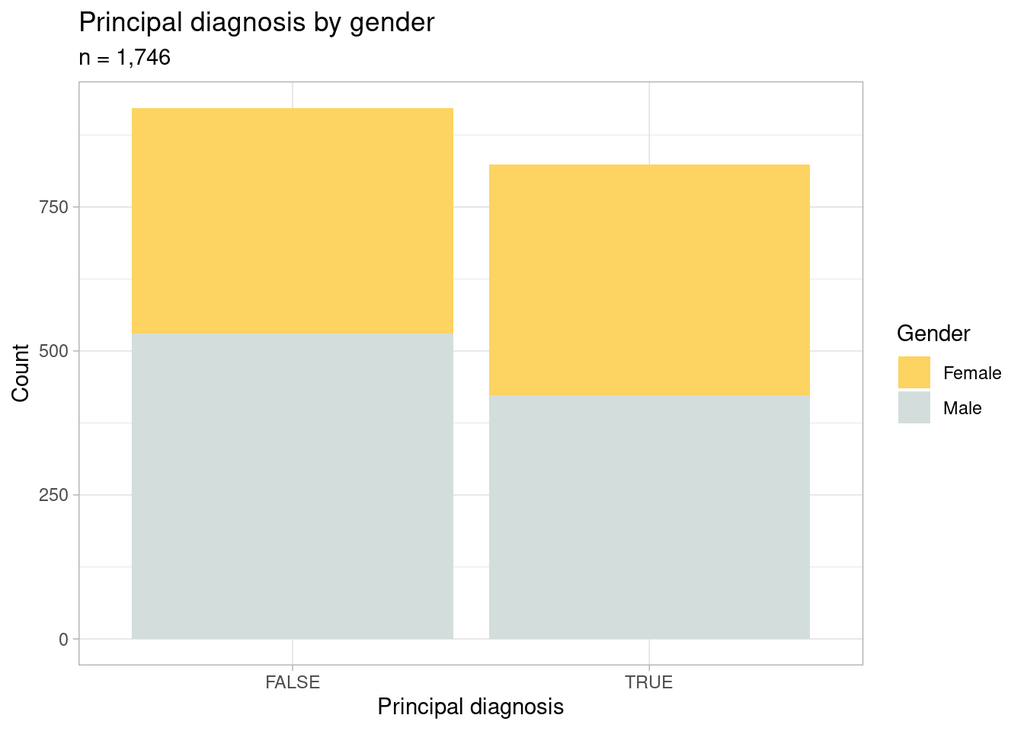

```r
study_admissions %>%
  arrange(subject_id, principal_dx) %>%
  group_by(subject_id, principal_dx) %>%
  filter(row_number() == 1) %>%
  ggplot +
  geom_bar(mapping = aes(x = principal_dx, fill = gender)) +
  scale_fill_manual(name = "Gender",
                    values = c("#FDD361","#D3DDDC"),
                    labels = c("Female", "Male")) +
  labs(title = "Principal diagnosis by gender",
       subtitle = "n = 1,746",
       x = "Principal diagnosis",
       y = "Count") +
  theme_light()
```

## Mortality

For patients who experienced mortality 30 days after discharge, there is a higher proportion of males.

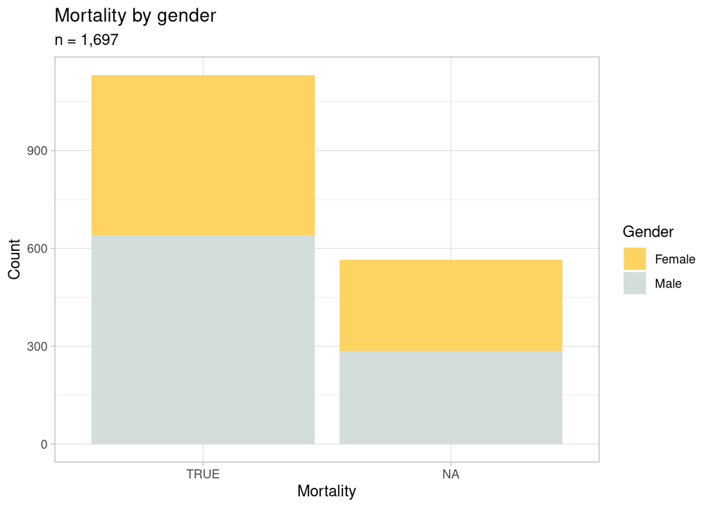

```r
study_admissions %>%
  arrange(subject_id, mortality) %>%
  group_by(subject_id, mortality) %>%
  filter(row_number() == 1) %>%
  ggplot +
  geom_bar(mapping = aes(x = mortality, fill = gender)) +
  scale_fill_manual(name = "Gender",
                    values = c("#FDD361","#D3DDDC"),
                    labels = c("Female", "Male")) +
  labs(title = "Mortality by gender",
       subtitle = "n = 1,697",
       x = "Mortality",
       y = "Count") +
  theme_light()
```

# Data analysis

## Creating training and testing samples

```r
df <- as.data.frame(study_admissions)
df <- replace_na(df, list(mortality = FALSE))

table(df$mortality)
```

```
##
## FALSE  TRUE
##  1010  1951
```

```r
set.seed(203)
sample <- sample(c(TRUE, FALSE), nrow(df), replace = T, prob = c(0.6, 0.4))

train <- df[sample, ]
test <- df[!sample, ]
```

## Logistic regression

To start off, I performed a logistic regression that included all the variables in the model.

```r
glm(mortality ~ age + drg_severity + principal_dx + gender +ethnic_group, data = train,
                  family = binomial(link = "logit"), maxit = 100) %>%
  summary()
```

```
##
## Call:
## glm(formula = mortality ~ age + drg_severity + principal_dx +
##     gender + ethnic_group, family = binomial(link = "logit"),
##     data = train, maxit = 100)
##
## Deviance Residuals:
##     Min       1Q   Median       3Q      Max
## -1.7019  -1.3794   0.8266   0.9251   1.2483
##
## Coefficients:
##                       Estimate Std. Error z value Pr(>|z|)
## (Intercept)          -0.407449   0.359991  -1.132  0.25771
## age                   0.011452   0.004075   2.811  0.00495 **
## drg_severity          0.121743   0.048423   2.514  0.01193 *
## principal_dxTRUE     -0.081207   0.101780  -0.798  0.42494
## genderM               0.243665   0.101645   2.397  0.01652 *
## ethnic_groupBLACK    -0.314672   0.278501  -1.130  0.25853
## ethnic_groupHISPANIC -0.246032   0.350467  -0.702  0.48267
## ethnic_groupUNKNOWN  -0.190024   0.296722  -0.640  0.52191
## ethnic_groupWHITE    -0.058920   0.234144  -0.252  0.80132
## ---
## Signif. codes:  0 '***' 0.001 '**' 0.01 '*' 0.05 '.' 0.1 ' ' 1
##
## (Dispersion parameter for binomial family taken to be 1)
##
##     Null deviance: 2299.6  on 1794  degrees of freedom
## Residual deviance: 2270.8  on 1786  degrees of freedom
## AIC: 2288.8
##
## Number of Fisher Scoring iterations: 4
```

To refine the model, I omitted the `principal diagnosis` and `ethnic group` variables since they did not appear to be statistically significant (p-values above 0.05). Therefore, I included only `age`, `DRG severity`, and `gender` in the logistic regression model.

```r
glm(mortality ~ age + drg_severity + gender, data = train,
                  family = binomial(link = "logit"), maxit = 100) %>%
  summary()
```

```
##
## Call:
## glm(formula = mortality ~ age + drg_severity + gender, family = binomial(link = "logit"),
##     data = train, maxit = 100)
##
## Deviance Residuals:
##     Min       1Q   Median       3Q      Max
## -1.7189  -1.3855   0.8280   0.9274   1.1986
##
## Coefficients:
##               Estimate Std. Error z value Pr(>|z|)
## (Intercept)  -0.582918   0.285755  -2.040  0.04136 *
## age           0.011998   0.004042   2.968  0.00299 **
## drg_severity  0.125363   0.047951   2.614  0.00894 **
## genderM       0.243976   0.101227   2.410  0.01594 *
## ---
## Signif. codes:  0 '***' 0.001 '**' 0.01 '*' 0.05 '.' 0.1 ' ' 1
##
## (Dispersion parameter for binomial family taken to be 1)
##
##     Null deviance: 2299.6  on 1794  degrees of freedom
## Residual deviance: 2274.4  on 1791  degrees of freedom
## AIC: 2282.4
##
## Number of Fisher Scoring iterations: 4
```

```r
logit_mod <- glm(mortality ~ age + drg_severity + gender, data = train,
                  family = binomial(link = "logit"), maxit = 100)
```

## ROC curve

```r
test$predicted <- plogis(predict(logit_mod, test))
roc <- pROC::roc(test$mortality, test$predicted)
```

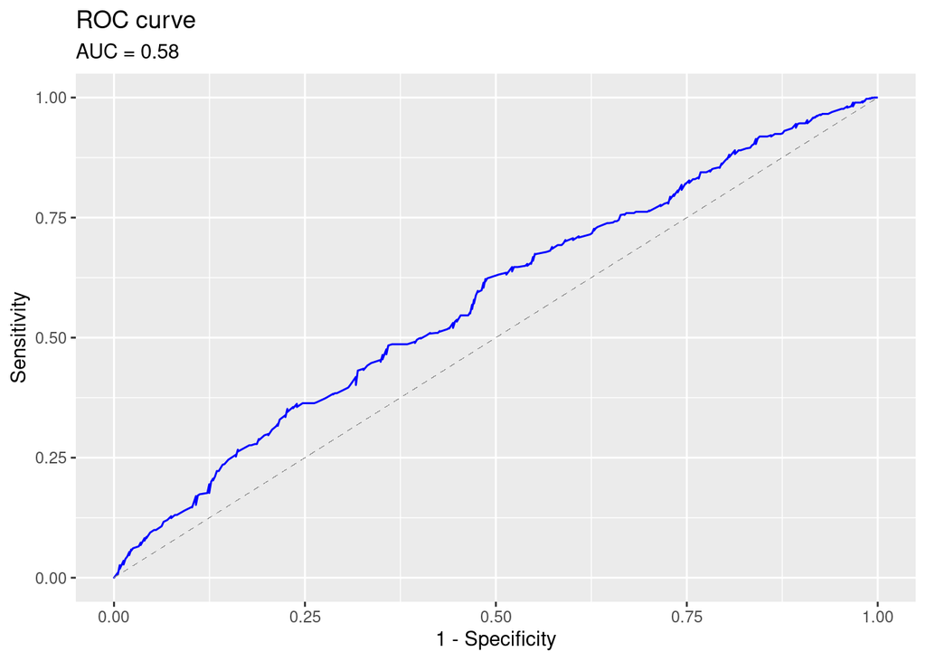

```r
newdf <- tibble(rep(NA, 356))
newdf$sens <- roc$sensitivities
newdf$spec <- roc$specificities

ggplot(newdf, aes(x = 1 - spec, y = sens)) +
  geom_line(color = "blue") +
  labs(title = "ROC curve",
       subtitle = str_c("AUC = ", round(roc$auc, digits = 2)),
       x = "1 - Specificity",
       y = "Sensitivity") +
  geom_segment(aes(x = 0, y = 0, xend = 1, yend = 1), linetype = "dashed", size = 0.02, color = "gray55")
```

# Closing the database connection

```r
dbDisconnect(con)
```

```
## [1] TRUE
```

# Conclusion

Overall, the logistic regression model with `age`, `DRG severity`, and `gender` for the 30-day mortality rate of cancer patients admitted into MICU is not a great predictor. The dashed line or line of no-discrimination represents a random guess, which results in an AUC value of 0.50. We see from the ROC curve figure that the AUC is about 0.58, which is not much higher than 0.50. Generally, an AUC of 0.70 to 0.80 is considered acceptable, 0.80 to 0.90 is considered excellent, and more than 0.90 is considered outstanding.

The model is limited because the majority of the study cohort consists of white patients, so these findings may not be applicable to minority ethnicity groups.

Furthermore, a neural network could potentially be used to build a predictive model and comapre the predictive performance. However, the `keras` package is not functioning properly, so this approach was not possible given the time constraints.